# Data mining in R - an example walkthrough using *Caret*

R offers algorithms for data mining in several packages.

One difficulty with these packages and functions is the fact that they all use slightly different syntax. The `caret`-package offers a unified interface to different data mining functions.

This write-up is not intended as documentation or vignette for the `caret`-package (visit the website http://topepo.github.io/caret/index.html), it shall just serve the purpose of a simple introduction in R’s data mining capabilities using this unified interface.

For this example, we will be using a dataset on artificial customer churn data. It is built into the R-package `C50` already.

## The churn dataset

From the description in R: (use `?C50`)

```r
library(C50)
data(churn)
?churnTrain
colnames(churnTrain)
```

```
##  [1] "state"                         "account_length"
##  [3] "area_code"                     "international_plan"
##  [5] "voice_mail_plan"               "number_vmail_messages"
##  [7] "total_day_minutes"             "total_day_calls"
##  [9] "total_day_charge"              "total_eve_minutes"
## [11] "total_eve_calls"               "total_eve_charge"
## [13] "total_night_minutes"           "total_night_calls"
## [15] "total_night_charge"            "total_intl_minutes"
## [17] "total_intl_calls"              "total_intl_charge"
## [19] "number_customer_service_calls" "churn"
```

The datasource describes as follows: *The second case study uses data from the data archive at MLC++ that concerns telecommunications churn. These data are artificial but are claimed to be “based on claims similar to real world.” Each case is described by 16 numeric and three nominal attributes and the data are divided into a training set of 3,333 cases and a separate test set containing 1,667 cases.*

```r
#head(churnTrain)
#summary(churnTrain)
```

The dataset comes as `churnTrain` and ``churnTest`; the training set contains 3333 observations, the test set 1667. The outcome (whether customer churned or not) is in the last column *churn*. Among explanatory variables we find information about the state, account length, area code, amount of calls etc.

## Graphical exploration

Our goal is to predict the **churn** from the other information provided. But before using algorithms we will visualize parts of the data in order to get a feel for possible patterns and relations (well, let’s say we pick the two variables we use in the plot just randomly…).

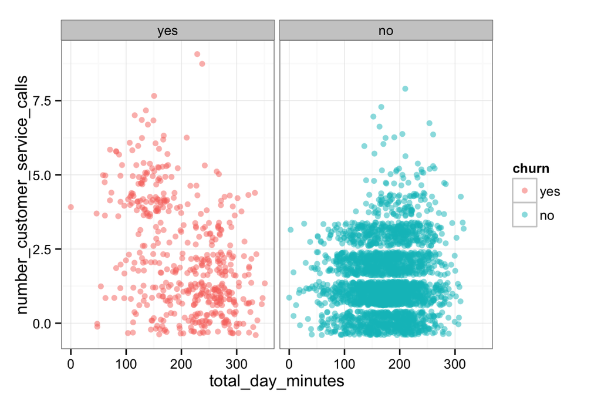

```r
library(ggplot2)
ggplot(data=churnTrain, aes(x=total_day_minutes, y=number_customer_service_calls)) + geom_point(aes(color=churn), position="jitter", alpha=0.5) + facet_wrap(~churn) + theme_bw()
```

We observe that in case of a lot of minutes spent on the phones the churn rate seems higher. The same holds true if a lot of customer calls had been taken.

Let’s now apply some data mining algorithms.

## Preparing the data

For our prediction, went to split the data into a training set and a test set. Reason for this is to avoid any overfitting of the data by the model.

Luckiliy the data set already is “split”; we have two data sets, i.e. `churnTrain` and `churnTest`.

However, we might incur a situation where some of the explanatory variables correlate. If we use methods like Trees, this is not a problem since the method itself discards “redundant” variables. For illustration purposes we nevertheless investigate the data for so-called multicollinearity. We first use a function from the `caret`-package called `findCorrelation`. We remove those variables from the dataset and run a PCA to investiagte for further linear combinations.

```r
library(caret)
index <- which(!sapply(churnTrain, is.numeric))
churn.nums <- churnTrain[,-index]
churn.corr <- cor(churn.nums)
(index <- findCorrelation(churn.corr, verbose=FALSE))
```

```
## [1] 14  8  9  5
```

```r
colnames(churn.nums[,index])
```

```
## [1] "total_intl_charge"   "total_eve_charge"    "total_night_minutes"
## [4] "total_day_charge"
```

```r
churn.nums.clean <- churn.nums[,-index]

churn.pca <- princomp(churn.nums.clean, cor= TRUE)
summary(churn.pca)
```

```
## Importance of components:
##                         Comp.1  Comp.2  Comp.3  Comp.4  Comp.5  Comp.6
## Standard deviation     1.04298 1.02738 1.01979 1.01121 1.00017 0.99428
## Proportion of Variance 0.09889 0.09596 0.09454 0.09296 0.09094 0.08987
## Cumulative Proportion  0.09889 0.19485 0.28939 0.38235 0.47329 0.56316
##                         Comp.7  Comp.8  Comp.9 Comp.10 Comp.11
## Standard deviation     0.98576 0.98447 0.98130 0.98093 0.96910
## Proportion of Variance 0.08834 0.08811 0.08754 0.08747 0.08538
## Cumulative Proportion  0.65150 0.73961 0.82715 0.91462 1.00000
```

```r
loadings(churn.pca)
```

```
##
## Loadings:
##                               Comp.1 Comp.2 Comp.3 Comp.4 Comp.5 Comp.6
## account_length                 0.479                0.123  0.458 -0.317
## number_vmail_messages                -0.381 -0.175 -0.374 -0.173 -0.654
## total_day_minutes                    -0.422  0.301  0.335  0.231  0.134
## total_day_calls                0.496  0.105  0.355 -0.273  0.189
## total_eve_minutes             -0.233 -0.360 -0.286 -0.109  0.524
## total_eve_calls                0.279 -0.133         0.552 -0.222 -0.292
## total_night_calls             -0.209 -0.448  0.233  0.245 -0.277  0.180
## total_night_charge                           0.603 -0.343 -0.271 -0.237
## total_intl_minutes             0.415        -0.346 -0.144 -0.379  0.295
## total_intl_calls               0.372 -0.334 -0.337        -0.211
## number_customer_service_calls -0.172  0.451 -0.101  0.376        -0.432
##                               Comp.7 Comp.8 Comp.9 Comp.10 Comp.11
## account_length                 0.176 -0.459                -0.440
## number_vmail_messages         -0.229         0.390
## total_day_minutes             -0.704  0.166                -0.141
## total_day_calls                              0.124 -0.228   0.657
## total_eve_minutes              0.231  0.347 -0.189 -0.482
## total_eve_calls                0.390  0.511  0.188
## total_night_calls              0.241 -0.534  0.137 -0.377   0.166
## total_night_charge                    0.183 -0.437 -0.203  -0.337
## total_intl_minutes            -0.162  0.147  0.209 -0.503  -0.335
## total_intl_calls                     -0.157 -0.683  0.189   0.237
## number_customer_service_calls -0.342        -0.197 -0.474   0.174
##
##                Comp.1 Comp.2 Comp.3 Comp.4 Comp.5 Comp.6 Comp.7 Comp.8
## SS loadings     1.000  1.000  1.000  1.000  1.000  1.000  1.000  1.000
## Proportion Var  0.091  0.091  0.091  0.091  0.091  0.091  0.091  0.091
## Cumulative Var  0.091  0.182  0.273  0.364  0.455  0.545  0.636  0.727
##                Comp.9 Comp.10 Comp.11
## SS loadings     1.000   1.000   1.000
## Proportion Var  0.091   0.091   0.091
## Cumulative Var  0.818   0.909   1.000
```

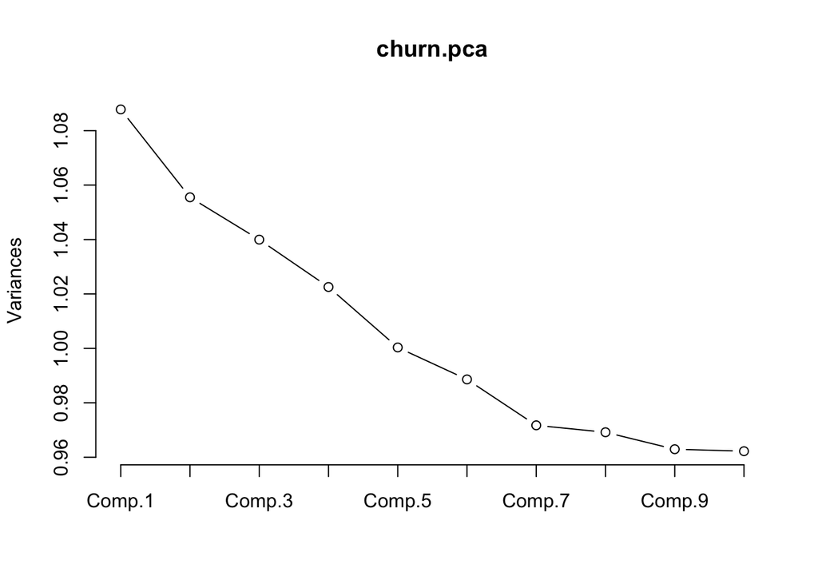

```r
plot(churn.pca, type="l")
```

```r
# par(mfrow=c(1,2))
# biplot(churn.pca, cex=c(.5,.75), col=c(0,2))
# biplot(churn.pca, choices=2:3, cex=c(.5,.75), col=c(0,2))
# par(mfrow=c(1,1))
```

The algorithm first suggests to remove those variables: total_intl_charge, total_eve_charge, total_night_minutes, total_day_charge.

These are mainly the *charges*: The dataset also contains *minutes* and charges and minutes seem to scale linearily. Also, we observe from the PCA on the remaining dataset that the *number of customer calls* is positive on the 2nd component, while *account length*, *daily calls*, *international minutes* scale positively on the 1st coponent. However, given that we already removed correlated variables, the screeplot shows that only with 10 out of 11 components 90% of variance can be explained - so there is low opportunity to reduce dimensionality.

For the remainder of the analysis we will continue using the complete dataset as we will employ techniques that perform feature selection as part of their algorithm, e.g trees.

## Building a tree

We can use the function `train` from the `caret-`package with the `method="rpart"`. The `rpart` package provides *Breiman et al.’s* CART-algorithm. We could also just use the `rpart`-package, but the purpose here is to show the capabilities of a unified interface with the `caret`-package.

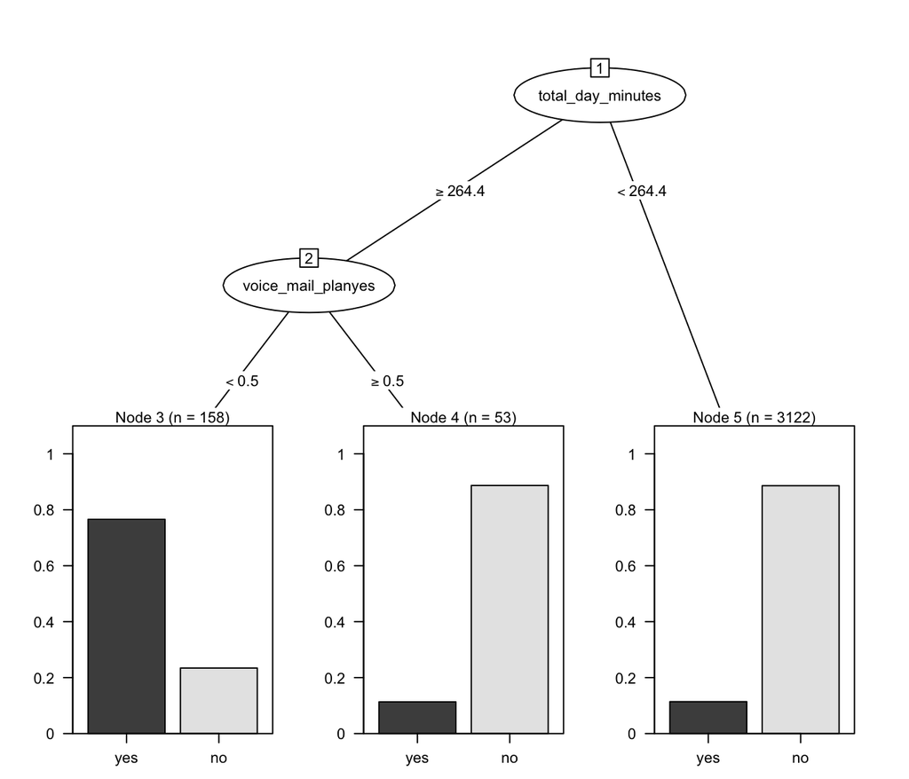

```r
set.seed(123)
tree_cart <- train(churn~., data=churnTrain, method="rpart") # that creates the tree
library(partykit) # we need this package to make the nice plot one line below
plot(as.party(tree_cart$finalModel), tp_args=list(beside=TRUE), gp=gpar(cex=0.7, las=0))
```

The object `tree_cart` is created, and a `rpart`-tree is fitted to it, using the training-data. `rpart` by default grows a full tree; the user quite likely will have to prune it afterwards. The implementation in `caret` however uses automatical bootstrapping for pruning on accuracy as metric. The `partykit`-package is used to make a nice plot. We can observe that - on the training set - the classes (churn/not churn) are reasonably well predicted; and customers have high likelihood to churn, if they consume a lot of daily minutes and have no voice mail plan.

The `caret`-package allows us to control some of the parameters. For example, the default is to use bootstrapping as a resampling scheme in the `rpart`-function. We can change that and use 10-fold cross-validation on the training set by creating a kind of “parameter object” and pass that to the `train`-function. Also we would like to use the value under the ROC curve as performance metric, that’s why we tell `train` to use class probabilities (instead of merely predicting the class binary) (`classProbs=TRUE`) and we add the `twoClassSummary`to include the ROC value.

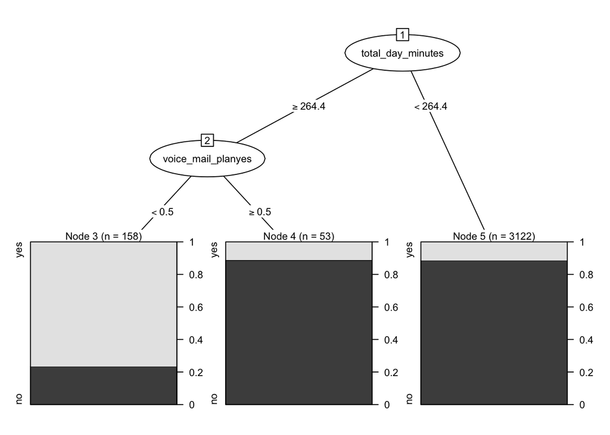

```r
cvCtrl <- trainControl(method="cv", number=10, classProbs=TRUE, summaryFunction=twoClassSummary)
set.seed(123)
tree_cart_cv <- train(churn~., data=churnTrain, method="rpart", trControl=cvCtrl, metric="ROC") # that creates the tree
#tree_cart_cv
#tree_cart_cv$finalModel
plot(as.party(tree_cart_cv$finalModel), tp_args=list(beside=FALSE), gp=gpar(cex=0.7, las=0))
```

```r
# tree_rpart <- train(churn~., data=churnTrain, method="rpart", trControl=trainControl(method="none"), tuneLength=1)
# tree_rpart$finalModel
#tree_rpart <- rpart(churn~., data=churnTrain, method="class")
#plot(as.party(tree_rpart), tp_args=list(beside=FALSE), gp=gpar(cex=0.7, las=0))
```

(If you typed `tree_cart` you’d see that there Bootstrapping was the resampling method and accuracy was used to select the optimal model)

The result is no different, though, in this case.

The final model is a “sub-object” in `tree_cart_cv`, you access it with the $-sign: `tree_cart_cv$finalModel`.

## Predict

After our model has been set-up and trained, we can use it to make a prediction. And we start predicting on the training set, to see how well we did there. Of course it will only become interesting when we predict against the test set, but that later…

```r
predict_train <- predict(tree_cart_cv, churnTrain)
confusionMatrix(predict_train, churnTrain$churn)
```

```
## Confusion Matrix and Statistics
##
##           Reference
## Prediction  yes   no
##        yes  121   37
##        no   362 2813
##
##                Accuracy : 0.88
##                  95% CI : (0.869, 0.891)
##     No Information Rate : 0.855
##     P-Value [Acc > NIR] : 1.28e-05
##
##                   Kappa : 0.33
##  Mcnemar's Test P-Value : < 2e-16
##
##             Sensitivity : 0.2505
##             Specificity : 0.9870
##          Pos Pred Value : 0.7658
##          Neg Pred Value : 0.8860
##              Prevalence : 0.1449
##          Detection Rate : 0.0363
##    Detection Prevalence : 0.0474
##       Balanced Accuracy : 0.6188
##
##        'Positive' Class : yes
##
```

```r
# predict_train_rpart <- predict(tree_rpart, churnTrain, type="class") #predicts the unprunded rpart
# confusionMatrix(predict_train_rpart, churnTrain$churn)
```

We first create an object that contains our prediction, using the model we just specified and using the training-data to predict on. We then create a confusion matrix (and a lot of other stuff…). Accuracy is about 0.88, kappa-statistic is about 0.3; the model seems to do fairly well.

As next step we predict on the test data.

```r
predict_test <- predict(tree_cart_cv, churnTest)
confusionMatrix(predict_test, churnTest$churn)
```

```
## Confusion Matrix and Statistics
##
##           Reference
## Prediction  yes   no
##        yes   60   24
##        no   164 1419
##
##                Accuracy : 0.887
##                  95% CI : (0.871, 0.902)
##     No Information Rate : 0.866
##     P-Value [Acc > NIR] : 0.00464
##
##                   Kappa : 0.341
##  Mcnemar's Test P-Value : < 2e-16
##
##             Sensitivity : 0.2679
##             Specificity : 0.9834
##          Pos Pred Value : 0.7143
##          Neg Pred Value : 0.8964
##              Prevalence : 0.1344
##          Detection Rate : 0.0360
##    Detection Prevalence : 0.0504
##       Balanced Accuracy : 0.6256
##
##        'Positive' Class : yes
##
```

The differences do not seem to be massive; normally one might expect worse performance on the out-of-sample set.

What we are now interested in is getting the ROC curve, and mainly calculating the AUC-value. Therefore we have to predict class probabilities rather than the classes itself.

```r
predict_probs <- predict(tree_cart_cv, churnTrain, type="prob")
tail(predict_probs)
```

```
##        yes    no
## 3328 0.114 0.886
## 3329 0.114 0.886
## 3330 0.114 0.886
## 3331 0.114 0.886
## 3332 0.114 0.886
## 3333 0.114 0.886
```

There are several packages that allow plotting of ROC curves; we will use `ROCR`. (A sidenote here: Depending on the function you sue, it is important to the function what the positive and what the negative class is. If you end up with AUC<0.5, you quite likely have mixed up positive and negative classes)

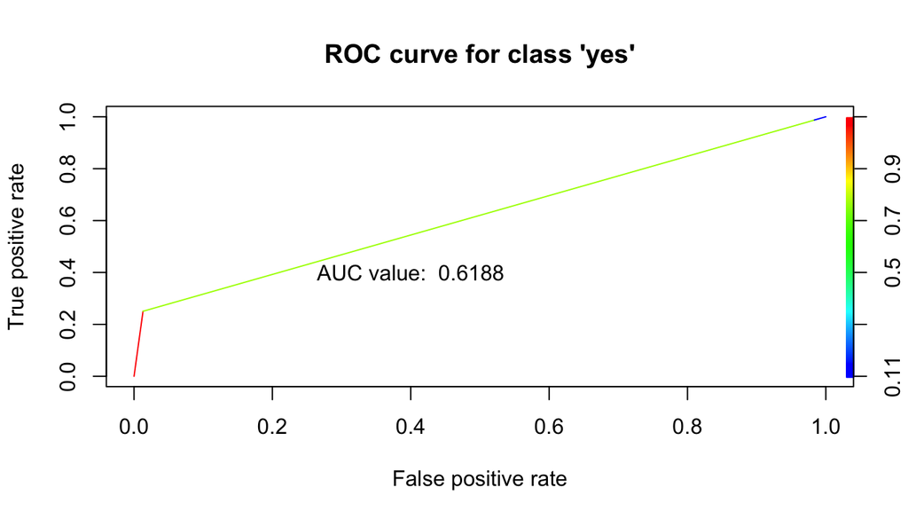

```r
# library(pROC)
# auc(churnTrain$churn, predict_probs$no)

library(ROCR)
preds_rocr <- prediction(predict_probs$yes, churnTrain$churn)
auc <- round(performance(preds_rocr, "auc")@y.values[[1]],4)
plot(performance(preds_rocr, "tpr", "fpr"), colorize=TRUE, main="ROC curve for class 'yes'")
text(x=.4, y=0.4, labels=paste("AUC value: ",auc))
```

The AUC value confirms that the tree-model predicts better than random.

## Compare multiple models

We train these models on the training data and present as measure of accuracy the ROC-value.

```r
library(RWeka)
# tree_j48 <- J48(churn~., data=churnTrain)
# evaluate_Weka_classifier(tree_j48, numFolds = 10, complexity = FALSE,
#     seed = 1, class = TRUE)

set.seed(123)
tree_j48_cv <- train(churn~., data=churnTrain, method="J48", trControl=cvCtrl) # that creates the tree
tree_j48_cv
```

```
## C4.5-like Trees
##
## 3333 samples
##   19 predictor
##    2 classes: 'yes', 'no'
##
## No pre-processing
## Resampling: Cross-Validated (10 fold)
##
## Summary of sample sizes: 3000, 3000, 2999, 2999, 3000, 3000, ...
##
## Resampling results
##
##   ROC  Sens  Spec  ROC SD  Sens SD  Spec SD
##   0.9  0.7   1     0.04    0.05     0.01
##
## Tuning parameter 'C' was held constant at a value of 0.25
##
```

```r
(tree_j48_cv$finalModel)
```

```
## J48 pruned tree
## ------------------
##
## total_day_minutes <= 264.4
## |   number_customer_service_calls <= 3
## |   |   international_planyes <= 0
## |   |   |   total_day_minutes <= 223.2: no (2221.0/60.0)
## |   |   |   total_day_minutes > 223.2
## |   |   |   |   total_eve_minutes <= 242.3: no (296.0/22.0)
## |   |   |   |   total_eve_minutes > 242.3
## |   |   |   |   |   voice_mail_planyes <= 0
## |   |   |   |   |   |   total_night_minutes <= 174.2
## |   |   |   |   |   |   |   total_day_minutes <= 246.8: no (12.0)
## |   |   |   |   |   |   |   total_day_minutes > 246.8: yes (5.0/1.0)
## |   |   |   |   |   |   total_night_minutes > 174.2
## |   |   |   |   |   |   |   stateKS <= 0: yes (46.0/6.0)
## |   |   |   |   |   |   |   stateKS > 0
## |   |   |   |   |   |   |   |   total_night_calls <= 110: yes (2.0)
## |   |   |   |   |   |   |   |   total_night_calls > 110: no (2.0)
## |   |   |   |   |   voice_mail_planyes > 0: no (20.0)
## |   |   international_planyes > 0
## |   |   |   total_intl_calls <= 2: yes (51.0)
## |   |   |   total_intl_calls > 2
## |   |   |   |   total_intl_minutes <= 13.1
## |   |   |   |   |   total_day_minutes <= 240: no (153.0/2.0)
## |   |   |   |   |   total_day_minutes > 240
## |   |   |   |   |   |   total_eve_minutes <= 245.6: no (15.0/1.0)
## |   |   |   |   |   |   total_eve_minutes > 245.6: yes (5.0/1.0)
## |   |   |   |   total_intl_minutes > 13.1: yes (43.0)
## |   number_customer_service_calls > 3
## |   |   total_day_minutes <= 160.2
## |   |   |   total_eve_charge <= 19.83
## |   |   |   |   voice_mail_planyes <= 0: yes (62.0)
## |   |   |   |   voice_mail_planyes > 0
## |   |   |   |   |   stateIL <= 0: yes (15.0/1.0)
## |   |   |   |   |   stateIL > 0: no (2.0)
## |   |   |   total_eve_charge > 19.83
## |   |   |   |   total_day_minutes <= 120.5: yes (10.0)
## |   |   |   |   total_day_minutes > 120.5
## |   |   |   |   |   area_codearea_code_415 <= 0
```

[output cut: 32 more lines]

```
## |   |   |   total_night_charge <= 5.71
## |   |   |   |   total_day_minutes <= 277: no (4.0)
## |   |   |   |   total_day_minutes > 277: yes (3.0)
## |   |   |   total_night_charge > 5.71: yes (94.0/1.0)
## |   voice_mail_planyes > 0
## |   |   international_planyes <= 0: no (45.0/1.0)
## |   |   international_planyes > 0
## |   |   |   area_codearea_code_415 <= 0: yes (3.0)
## |   |   |   area_codearea_code_415 > 0
## |   |   |   |   account_length <= 99: no (3.0)
## |   |   |   |   account_length > 99: yes (2.0)
##
## Number of Leaves  :  41
##
## Size of the tree :   81
```

```r
predict_probs_j48 <- predict(tree_j48_cv, churnTrain, type="prob")

## C5.0
set.seed(123)
tree_c5_cv <- train(churn~., data=churnTrain, method="C5.0Tree", trControl=cvCtrl) # that creates the tree
#tree_c5_cv
#summary(tree_c5_cv$finalModel)
predict_probs_c5 <- predict(tree_c5_cv, churnTrain, type="prob")


## SVM
# library(kernlab)
# set.seed(123)
# #NOTE: Cannot get SVM running with caret for whatever reason....
# #svmTune <- ksvm(Species~., data=train,prob.model=TRUE)
# svmTune <- train(Species~., data=train, method="svmRadial", trControl=cvCtrl) # that creates the tree
# predict_svm <- predict(svmTune, as.data.frame(test)[,-5], type="prob")
#
# kNN
knnFit <- train(churn~., data=churnTrain, method = "knn", trControl = cvCtrl)
predict_knn <- predict(knnFit, churnTrain, type="prob")

#compare different models
#the problem seems to be how CARET treats factor variables. It blows the colums up, e.g. "stateAL"
modelObjects <- list(cart=tree_cart_cv,
                     j48=tree_j48_cv,
                     c50=tree_c5_cv,
                     knn=knnFit)
#predict(modelObjects, churnTrain)

#sapply(modelObjects, function(x) x$method)
x <- data.frame(ROC=sort(sapply(modelObjects, function(x) max(x$results$ROC)), decreasing=TRUE))
x
```

```
##         ROC
## c50  0.8995
## j48  0.8656
## knn  0.6651
## cart 0.5130
```

We observe that C50 and J48 perform similarly, while kNN and CART are significantly worse.

We can also perform a resampling of the models to get a feeling for stability

```r
# variances in resamples.
cvValues <- resamples(list(CART=tree_cart_cv, C50=tree_c5_cv, J48=tree_j48_cv, kNN=knnFit))
summary(cvValues)
```

```
##
## Call:
## summary.resamples(object = cvValues)
##
## Models: CART, C50, J48, kNN
## Number of resamples: 10
##
## ROC
##       Min. 1st Qu. Median  Mean 3rd Qu.  Max. NA's
## CART 0.291   0.367  0.410 0.513   0.726 0.755    0
## C50  0.813   0.886  0.905 0.899   0.919 0.952    0
## J48  0.814   0.838  0.864 0.866   0.896 0.916    0
## kNN  0.602   0.643  0.668 0.665   0.688 0.717    0
##
## Sens
##       Min. 1st Qu. Median  Mean 3rd Qu.  Max. NA's
## CART 0.188   0.269  0.351 0.346   0.405 0.479    0
## C50  0.612   0.688  0.698 0.723   0.762 0.854    0
## J48  0.633   0.708  0.740 0.727   0.767 0.792    0
## kNN  0.208   0.240  0.299 0.281   0.312 0.327    0
##
## Spec
##       Min. 1st Qu. Median  Mean 3rd Qu.  Max. NA's
## CART 0.930   0.980  0.982 0.976   0.989 0.993    0
## C50  0.961   0.977  0.986 0.982   0.989 0.996    0
## J48  0.951   0.977  0.986 0.980   0.989 0.993    0
## kNN  0.965   0.969  0.974 0.978   0.986 0.993    0
```

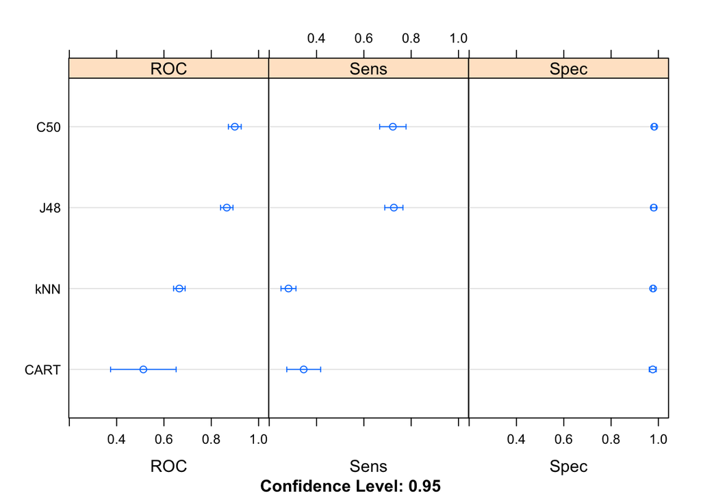

```r
dotplot(cvValues)
```

So, what’s missing? Clearly, we should now run the chosen algorithm against the testset to see how it performs there. This is left for later….